# Precificação de Contratos de Renda Variável

Ross et al. (2022), capítulo 08

Marcelo S. Perlin

EA-UFRGS

05/10/2026

# Introdução a valoração de ações

## Fluxos de caixa na compra de ações (situação mais comum)

> Uma ação é a menor parte do capital social da empresa, dando direito ao recebimento de parte do lucro da empresa em cada exercício futuro.
- Contrato é comprado pelo preço $P_0$
- Ao longo da vida do contrato, proventos na forma de dividendos são pagos ao acionista
- Contrato pode ser vendido ao preço $P_T$
- último dividendo $DIV_T$ é pago no tempo $T$

## Ilustração fluxos de caixa de ações

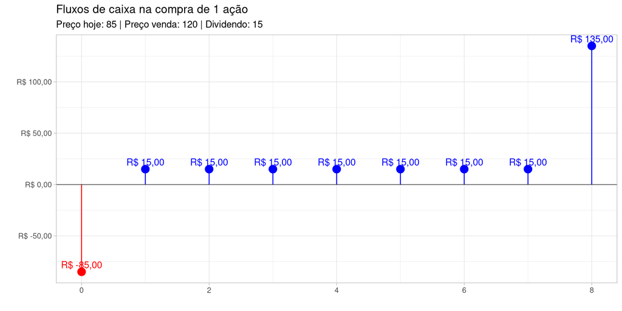

## Fluxos de caixa na compra de GGBR4 (Gerdau)

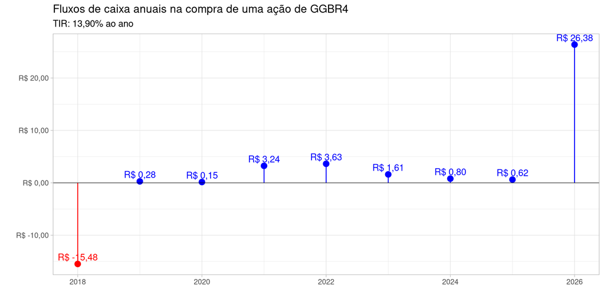

## Por que precificar uma ação?

- Estimar se o preço de mercado está acima (sobrepreço) ou abaixo (desconto) do preço justo
  - discussão sobre a eficiência do mercado financeiro
  - planejamento de estratégias de negociação
- Estipular o preço de contratos customizados (e.g. bônus de diretores)

## Precificação de um contrato de ação

A fórmula do valor presente (PV) nos diz que:

$$VP = \sum _{t=1} ^{T} \frac{FC}{(1+r)^t} + \frac{VF}{(1+r)^T}$$

Substituindo os símbolos para ação ($D$ = dividendos, $P_0$ = preço de compra e $P_T$ = preço de venda), temos:

$$P_0 = \sum _{t=1} ^{T} \frac{D}{(1+r)^t} + \frac{P_T}{(1+r)^T}$$

Para o exemplo anterior, e assumindo que $r = 0.1375$:

$$P_0 = \sum _{t=1} ^{8} \frac{15}{(1+0.1375)^t} + \frac{120}{(1+0.1375)^8} = 112.9829493$$

Note que o último fluxo de caixa ($t = 8$) é 120 + 15, isto é, o preço de venda **mais** o último dividendo.

# Modelo de Gordon – (Gordon and Shapiro 1956)

## Premissas

- Ações são mantidas até o infinito, com o pagamento periódico dos proventos (dividendos)
- O valor nominal dos dividendos são conhecidos e:
  - **Versão 01**: Constantes
  - **Versão 02**: Variáveis, com uma taxa de crescimento conhecida
  - **Versão 03**: taxa de crescimento variável
- O valor do preço da ação no futuro é desconhecido
- A taxa de crescimento deve ser **menor** que a taxa de desconto ($g < r$); se $g \geq r$, o preço tende ao infinito (ou fica negativo) e o modelo não faz sentido

## Derivação Versão 01 (dividendos constantes)

- a ação paga o valor $DIV$ em cada período, indefinidamente
- não é preciso assumir uma venda futura: como $T \to \infty$, o valor de revenda $P_T$ se torna irrelevante

O valor presente de uma perpetuidade constante é:

$$P_0 = \sum _{t=1} ^{\infty} \frac{DIV}{(1+r)^t}$$

Sabendo que $\sum _{t=1} ^{\infty} \frac{DIV}{(1+r)^t} = \frac{DIV}{r}$, temos:

$$P_0 =\frac{DIV}{r}$$

## Derivação Versão 02 (dividendos crescentes)

- a ação paga o valor $DIV_t$ em cada período, indefinidamente
- o dividendo cresce a uma taxa constante $g$: $DIV_t = DIV_0(1+g)^t$
- aqui $DIV_0$ é o dividendo **já pago** (tempo 0); o **próximo** dividendo é $DIV_1 = DIV_0(1+g)$

O valor presente da perpetuidade crescente é:

$$P_0 = \sum _{t=1} ^{\infty} \frac{DIV_0(1+g)^t}{(1+r)^t}$$

Sabendo que $\sum _{t=1} ^{\infty} \frac{DIV_0(1+g)^t}{(1+r)^t} = \frac{DIV_0(1+g)}{r-g}$, temos (requer $g < r$):

$$P_0 = \frac{DIV_0(1+g)}{r-g} = \frac{DIV_1}{r-g}$$

## Exemplo

> Uma empresa paga hoje dividendos de R$ 10,00. Considerando um custo de capital de 12,00% e uma taxa de crescimento de dividendos de 5,00%, qual o preço da ação hoje?

$$P_0 = \frac{DIV_0(1+g)}{r-g}$$
$$P_0 = \frac{10*(1+0.05)}{0.12-0.05}$$
$$P_0 = 150$$

## Sensibilidade do preço a $r$ e $g$

Preço justo (P0) para diferentes taxas de desconto (r) e crescimento (g)

| Crescimento (g) | 10,00% | 12,00% | 14,00% |
| --- | --- | --- | --- |
| 3,00% | R$ 147,14 | R$ 114,44 | R$ 93,64 |
| 5,00% | R$ 210,00 | R$ 150,00 | R$ 116,67 |
| 7,00% | R$ 356,67 | R$ 214,00 | R$ 152,86 |

Pequenas mudanças em $r$ ou $g$ causam **grandes** mudanças no preço: com $r = 10\%$, o preço vai de R$ 147,14 a R$ 356,67 só porque $g$ passou de 3% para 7%.

## Derivação Versão 03 (dividendos variáveis)

- flexibiliza o crescimento dos dividendos. Podemos ter uma época de grande crescimento, e outra de estabilidade.
- Não é preciso prever um preço de venda: o valor ao fim do primeiro estágio é calculado como uma perpetuidade (Gordon) sobre os dividendos seguintes

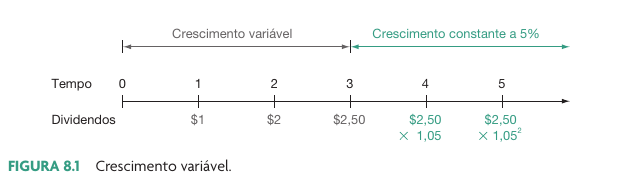

Extraído de Ross et al. (2022), página 243

## Exemplo (1/2)

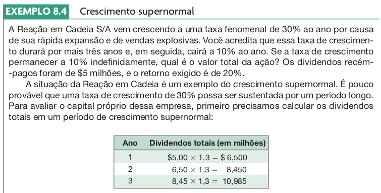

Extraído de Ross et al. (2022), página 243

## Exemplo (2/2)

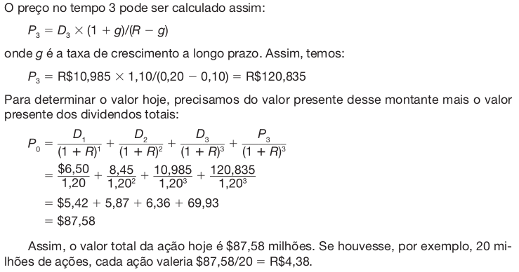

Extraído de Ross et al. (2022), página 243

## Versão 03 na prática: dois estágios

$$P_0 = \underbrace{\sum_{t=1}^{5}\frac{DIV_0(1+g_1)^t}{(1+r)^t}}_{\text{1º estágio}} +
\underbrace{\frac{1}{(1+r)^{5}}\cdot\frac{DIV_{6}}{r-g_2}}_{\text{perpetuidade}}$$

Assim, $P_0 = R$ 184,78$, dos quais 70,69% vêm apenas da **perpetuidade**.

## Versão 03 na prática: composição do valor

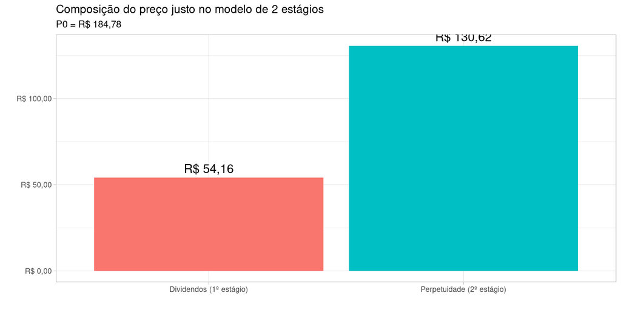

## Extraindo Informações do Modelo de Gordon

- Preços de ações são facilmente obtidos no mercado secundário
- Informações de dividendos pagos historicamente são públicas
  - permite o cálculo da taxa de crescimento dos dividendos
- Com base nisso, podemos calcular o valor de $r$, o qual representa a **taxa exigida de retorno** do mercado financeiro.
  - a taxa exigida pode ser usada como custo de capital em projetos da empresa

## Matemática

Para a versão 02 de Gordon, temos:

$$P_0 = \frac{DIV_0(1+g)}{r-g}$$

Isolando o $r$:

$$r = \frac{DIV_0(1+g)}{P_0}+g$$

$$r = \frac{DIV_1}{P_0}+g$$

Isto é, sabendo preço da ação hoje $P_0$, o custo de capital dos investidores pode ser extraído através da fórmula anterior

## De onde vem o $g$?

Estimar $g$ a partir do histórico de dividendos é frágil: os pagamentos são irregulares e o passado não garante o futuro. Uma alternativa é o **crescimento sustentável**:

$$g = ROE \times (1 - payout)$$

- uma empresa só cresce de forma perpétua retendo parte do lucro ($1 - payout$) e reinvestindo a uma taxa $ROE$
- use essa estimativa como **checagem** do $g$ histórico, e não como verdade absoluta

## Exemplo EGIE3.SA

- Em 02/10/2026 a ação EGIE3 estava cotada a R$ 30,70
- No seu histórico de dividendos, entre 01/01/2018 e 02/10/2026, vemos uma taxa de crescimento anual (CAGR) de -2,96%

Assim, temos:

$P_0 = R$ 30,70$

$g = -2,96%$

Aplicando a fórmula:

$r = \frac{DIV_0(1+g)}{P_0} + g$

$r = 7,45%$

Isso quer dizer que os investidores usam uma taxa de custo de capital de 7,45% ao ano para precificar os fluxos de caixa da empresa com ticker EGIE3

> **Atenção:** estimativas de $g$ e $r$ a partir de dados históricos são sensíveis ao período escolhido. Dividendos irregulares podem gerar valores pouco realistas — interprete o resultado como uma aproximação.

# Críticas ao modelo de Gordon

## Críticas

- Tempo infinito?
  - A imensa maioria dos investidores têm interesse em vender a ação antes de morrer!!
  - A empresa pode entrar em processo de falência?
    - Exemplo: Varig
- Dividendos crescentes?
  - Empresa não dá prejuízo, nunca?
  - Considere 2 empresas concorrentes: as mesmas teriam dividendos crescentes sempre?
- Sensibilidade extrema: pequenas mudanças em $r$ ou $g$ mudam muito o preço (e $g$ é difícil de estimar!)

## E o que fazer então?

- O modelo de Gordon é um **ponto de partida**, não a resposta final
- Alternativas usuais:
  - DDM multinível (Versão 03) para tratar fases de crescimento
  - Fluxo de caixa descontado (FCFE / FCFF) quando os dividendos não representam o potencial da empresa
  - Múltiplos comparáveis (P/L, EV/EBITDA) como checagem de preço relativo
- Na prática, o analista combina abordagens e procura um **intervalo** de preço justo, e não um número único

# A precificação na prática

## Como funciona a precificação na prática?

- Análise Fundamentalista / Valuation
  - Análise de balanços e informações financeiras
  - Construção de cenários econômicos e projeções de lucro
- Análise Técnica (Grafista)
  - Análise da história dos ativos (preços e volumes negociados)
  - Identificação de padrões de tendência (subida ou descida das ações) com base apenas em gráficos

## Referências

Gordon, Myron J, and Eli Shapiro. 1956. “Capital Equipment Analysis: The Required Rate of Profit.” *Management Science* 3 (1): 102–10.

Ross, Stephen, Randolph Westerfield, Bradford Jordan, et al. 2022. *Fundamentos de Administração Financeira*. Bookman Editora.